# Fifty States Project

7/15/2022

## Data Source and Procedures

### Open Source Software & Publicly Available Data

- GSOM (Global Summary of Monthly Data)
- Analysis and Graphics R/Rstudio
- Selected Station with longest records and fewest missing data
- Select month had strongest trend
- Evaluate Monthly Temp. Max and Min for trends

## Weather Station Selected

- Station ID ASHLAND, OR US (ID: GHCND:USC00350304)
- Records begin: 1892
- Records end: 2022
- Not necessarily representative of the state or similar to other stations in Oregon!

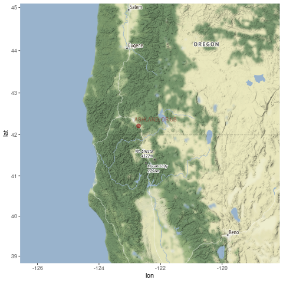

## Months with Largest Changes

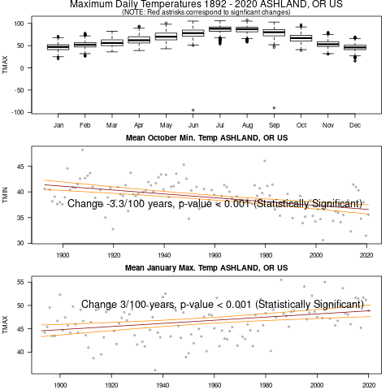

## Record Temperatures

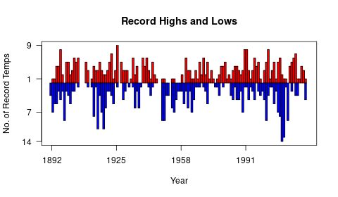

## Max. Temperature Anomaly Trend

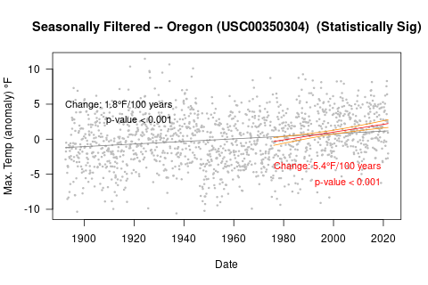

## Impacts

- Oregon’s climate is changing.
- Over the past century, most of the state has warmed about two degrees (F).
- Snowpack is melting earlier in the year, and the flow of meltwater into streams during summer is declining.
- In the coming decades, coastal waters will become more acidic, streams will be warmer, wildfires may be more common, and some rangelands may convert to desert.

[EPA Snapshot](https://19january2017snapshot.epa.gov/sites/production/files/2016-09/documents/climate-change-or.pdf)

## State Adaptation / Mitigation Plans

- Beginning with a 2006, Governor’s Climate Change Integration Group (CCIG), with representation from industry leaders, nonprofit organizations, and representatives from federal, state, and local government, Oregon continues to plan for climate change.
- On January 19, 2021, the state released a new version of the Oregon Climate Change Adaptation Framework to provide an updated guide to ensuring Oregon’s people, ecosystems, and economy are able to adapt to the impacts of a changing climate.
- The 2021 Framework is divided into five sections: Why We Must Adapt; Implementing Comprehensive Climate Change Adaptation; Climate Change Effects and Strategic Responses by Theme; Next Steps; and the Oregon Climate Equity Blueprint.
- The 2021 Framework was developed by a Working Group, composed of 24 state agencies, and coordinated by the Department of Land Conservation and Development.

[Source: Georgetown Climate Center] (https://www.georgetownclimate.org/adaptation/state-information/oregon/overview.html)

## Next Steps

- Put ideas in comments how what other can do to support state efforts
- Be kind: Responding to climate change includes a complex array of ethical issues.
- “Be curious”, Ted Lasso.